# Temporal Expression and Overlap Analysis of Doxycycline Response in Mouse Stem Cells

Patrick Frankel and Quinten Kinney

2025-03-18

## Introduction

This analysis examines the effects of doxycycline (dox) treatment on gene expression in mouse stem cells over time. Understanding doxycycline’s effects on gene expression is crucial when interpreting results from experiments using doxycycline-controlled systems. We’ll use the RNA-seq data processed through a NF-CORE pipeline to identify significant changes in gene expression, temporal patterns, and expression overlap affected by doxycycline treatment. Our analysis focuses on identifying differentially expressed genes at multiple time points (12, 24, 48, and 96 hours) compared to baseline (0 hours), allowing us to characterize both the magnitude and temporal dynamics of doxycycline’s effects. By examining when genes first become differentially expressed and how expression patterns persist or change across time points, we can uncover potential direct and indirect effects of doxycycline treatment.

## Loading and Processing Data

In this section, we prepare the RNA-seq data for analysis by loading the count matrix generated from the NF-CORE pipeline and creating appropriate metadata for the DESeq2 analysis. The goal is to organize the sample information properly to enable accurate differential expression testing across time points.

### Loading Count Matrix and Sample Information

```r
# Load counts matrix from salmon merged gene counts
counts_matrix <- read.table("/scratch/Shares/rinnclass/MASTER_CLASS/STUDENTS/pafr7911/MASTER_CLASS/data/salmon.merged.gene_counts.tsv", header = TRUE, row.names = 1)

# Create gene ID to gene name conversion table
g2s <- data.frame(
  gene_id = rownames(counts_matrix),
  gene_name = counts_matrix[, 1]
)

# Remove gene name column for DESeq2 analysis
counts_matrix <- counts_matrix[, -1]

# Round counts to integer mode required for DESeq2
counts_integer <- round(counts_matrix)
```

### Creating Sample Metadata for DESeq2

```r
# Create sample information dataframe
deseq_samples <- data.frame(
  sample_id = colnames(counts_matrix))

# Extract time point and replicate information from sample IDs
split_values <- strsplit(deseq_samples$sample_id, "_")
time_values <- sapply(split_values, function(x) x[[2]])
replicate_values <- sapply(split_values, function(x) x[[3]])

# Add time point and replicate columns to sample information
deseq_samples$time_point <- time_values
deseq_samples$replicate <- replicate_values

# Convert time point and replicate to factors (required for DESeq2)
deseq_samples$time_point <- factor(deseq_samples$time_point)
deseq_samples$replicate <- factor(deseq_samples$replicate)

# Set row names for DESeq2
deseq_samples <- column_to_rownames(deseq_samples, "sample_id")

# Verify column and row names match
stopifnot(all(colnames(counts_integer) == rownames(deseq_samples)))
```

### Discussion

This data processing approach effectively handles the count matrix by creating a gene ID to gene name conversion table, which will be useful for biological interpretation later.

## Differential Expression Analysis

This next section aims to identify genes significantly affected by doxycycline treatment using various stringency thresholds with the DESeq results. By applying different cutoffs for fold change and adjusted p-values, we can differentiate subtle changes with highly robust signals. This step is crucial for downstream analyses as it determines which genes will be examined for temporal patterns. We can also begin identifying which genes exhibit expression overlap in multiple time points and separate upregulated and downregulated genes.

### Running DESeq2

```r
# Create DESeq2 dataset
dds_time_point <- DESeqDataSetFromMatrix(countData = counts_integer,
                                        colData = deseq_samples,
                                        design = ~ time_point + replicate)

# Run DESeq2 analysis
dds_time_point <- DESeq(dds_time_point) # This takes ~1 min

# Extract results
result_names <- resultsNames(dds_time_point)[-1]  # Remove intercept

# Filter only for time point comparisons (removing replicate comparisons)
time_point_results <- result_names[grep("time_point", result_names)]

# Create empty dataframe to store all results
res_df <- data.frame()

# Get results for each comparison
for(results_name in time_point_results) {
  res <- results(dds_time_point, name = results_name)
  tmp_res_df <- res %>%
    as.data.frame() %>%
    rownames_to_column("gene_id") %>%
    merge(g2s) %>%
    mutate(result_name = results_name)
  res_df <- bind_rows(res_df, tmp_res_df)
}

# See NAs in adjusted p-values
na_count <- sum(is.na(res_df$padj))
cat("Number of NA adjusted p-values:", na_count, "\n")
```

```
## Number of NA adjusted p-values: 162412
```

### Filtering Significant Genes

```r
# Moderate threshold: Log2FC > 0.58 (1.5-fold change) and adjusted p-value < 0.05
filtered_res_df_moderate <- res_df %>%
  filter(padj < 0.05, abs(log2FoldChange) > 0.58)

# Stringent threshold: Log2FC > 1 (2-fold change) and adjusted p-value < 0.05
filtered_res_df_stringent <- res_df %>%
  filter(padj < 0.05, abs(log2FoldChange) > 1)

# Very stringent threshold: Log2FC > 2 (4-fold change) and adjusted p-value < 0.01
filtered_res_df_very_stringent <- res_df %>%
  filter(padj < 0.01, abs(log2FoldChange) > 2)

# Count unique genes at each threshold
sig_genes_moderate <- unique(filtered_res_df_moderate$gene_id)
sig_genes_stringent <- unique(filtered_res_df_stringent$gene_id)
sig_genes_very_stringent <- unique(filtered_res_df_very_stringent$gene_id)

cat("Number of significant genes (moderate threshold):", length(sig_genes_moderate), "\n")
```

```
## Number of significant genes (moderate threshold): 1339
```

```r
cat("Number of significant genes (stringent threshold):", length(sig_genes_stringent), "\n")
```

```
## Number of significant genes (stringent threshold): 535
```

```r
cat("Number of significant genes (very stringent threshold):", length(sig_genes_very_stringent), "\n")
```

```
## Number of significant genes (very stringent threshold): 40
```

```r
# Examine overlap between thresholds (simply a sanity check here)
moderate_stringent_overlap <- length(intersect(sig_genes_moderate, sig_genes_stringent))
stringent_very_stringent_overlap <- length(intersect(sig_genes_stringent, sig_genes_very_stringent))

cat("Overlap between moderate and stringent thresholds:", moderate_stringent_overlap, "\n")
```

```
## Overlap between moderate and stringent thresholds: 535
```

```r
cat("Overlap between stringent and very stringent thresholds:", stringent_very_stringent_overlap, "\n")
```

```
## Overlap between stringent and very stringent thresholds: 40
```

```r
# Create a list of significant genes at the stringent threshold for further analysis
sig_genes_for_analysis <- data.frame(gene_id = sig_genes_stringent)
```

### Discussion

A quick look at the filtered results shows substantial numbers of differentially expressed genes even at stringent thresholds (log2FC > 1, padj < 0.05), indicating doxycycline has widespread effects on gene expression in mouse stem cells. However, we have already seen these results before; the overlap data now provides a unique perspective between threshold categories, suggesting a core set of strongly affected genes alongside others with more modest responses. For further analysis, we selected the stringent threshold (log2FC > 1, padj < 0.05) to capture meaningful biological changes and provide us with enough *notable* data to parse and interpret. It may be of interest to the reader to use the moderate threshold instead, depending on prior knowledge of the importance of certain genes identified within this threshold, but not the latter two.

## Data Visualization

Now, we will visually explore how gene expression changes over time following doxycycline treatment. The following visualization shows the total number of up- and downregulated genes at each time point, which may help identify when dox is most potent in vitro. This temporal profiling is essential for understanding whether doxycycline’s impact is immediate, delayed, sustained, absent, or influences a different, unique expression pattern.

### Up & Down Regulation Summary

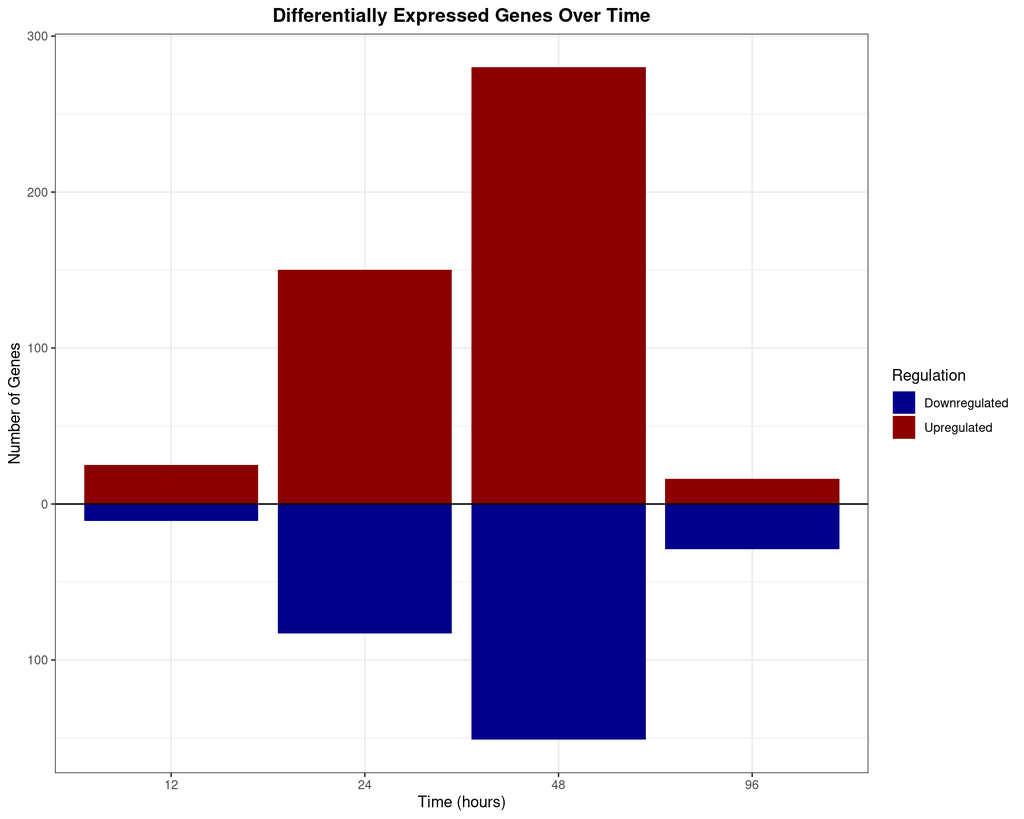

```r
# Extract time points for timepoint comparisons
unique_timepoints <- unique(gsub("time_point_|_vs_0", "", time_point_results))
unique_timepoints <- unique_timepoints[order(as.numeric(unique_timepoints))]

# Summary of significant genes across time points - exxcludes replicates
time_summary <- filtered_res_df_stringent %>%
  filter(grepl("time_point", result_name)) %>%
  group_by(result_name) %>%
  summarize(
    total_sig = n(),
    upregulated = sum(log2FoldChange > 0),
    downregulated = sum(log2FoldChange < 0)
  ) %>%
  mutate(
    time = gsub("time_point_|_vs_0", "", result_name),
    time = factor(time, levels = unique_timepoints)
  )

# Create a summary bar plot
ggplot(time_summary, aes(x = time)) +
  geom_bar(aes(y = upregulated, fill = "Upregulated"), stat = "identity") +
  geom_bar(aes(y = -downregulated, fill = "Downregulated"), stat = "identity") +
  scale_fill_manual(values = c("Upregulated" = "darkred", "Downregulated" = "darkblue")) +
  labs(title = "Differentially Expressed Genes Over Time",
       x = "Time (hours)",
       y = "Number of Genes",
       fill = "Regulation") +
  theme_bw() +
  theme(legend.position = "right",
        plot.title = element_text(hjust = 0.5, face = "bold")) +
  geom_hline(yintercept = 0, linetype = "solid", color = "black") +
  scale_y_continuous(labels = function(x) abs(x))
```

### Discussion

This visualization reveals a clear temporal pattern in doxycycline’s effects on gene expression. The most dramatic changes occur at 48 hours, with 280 upregulated and 151 downregulated genes. Interestingly, the response begins more modestly at 12 hours, increases substantially by 24 hours, peaks at 48 hours, and then diminishes by 96 hours to a level comparable to the 12 hour time point. This response curve suggests a transient effect of doxycycline on gene expression. The dominance of upregulation over downregulation indicates that doxycycline activates high-fold-change (stringent threshold) genes more frequently than it represses them in these cells.

- The `time_summary` table with the total number of differentially expressed genes over time

| Time Point | Total Sig | Upregulated Genes | Downregulated Genes |
| --- | --- | --- | --- |
| 12 hours | 36 | 25 | 11 |
| 24 hours | 233 | 150 | 83 |
| 48 hours | 431 | 280 | 151 |
| 96 hours | 45 | 16 | 29 |

### Response Timing Analysis

This analysis examines when genes first show significant differential expression following doxycycline treatment. By identifying the earliest time point at which each gene becomes differentially expressed–and the magintude by which there are–we can distinguish between immediate-early responders and genes that change only after prolonged exposure. This helps separate potential direct targets from secondary targets of doxycycline.

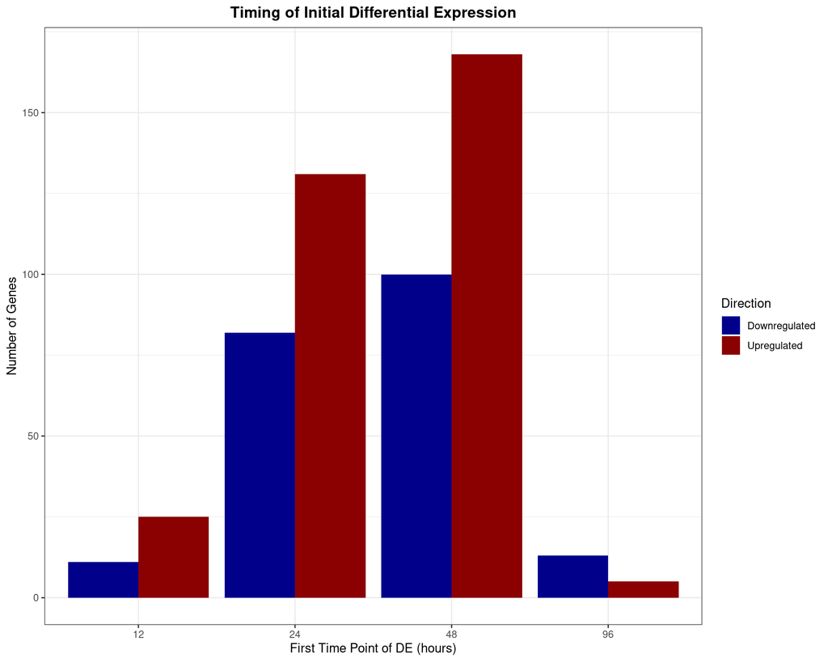

```r
# Identify when each gene first becomes differentially expressed
first_de_timepoint <- filtered_res_df_stringent %>%
  group_by(gene_id, gene_name) %>%
  summarize(
    first_de_time = min(as.numeric(gsub("time_point_|_vs_0", "", result_name))),
    direction_at_first_de = ifelse(
      log2FoldChange[which.min(as.numeric(gsub("time_point_|_vs_0", "", result_name)))] > 0,
      "Upregulated", "Downregulated"),
    fc_at_first_de = log2FoldChange[which.min(as.numeric(gsub("time_point_|_vs_0", "", result_name)))],
    .groups = "drop"
  )

# Count genes by first time point and direction
timing_summary <- first_de_timepoint %>%
  group_by(first_de_time, direction_at_first_de) %>%
  summarize(count = n(), .groups = "drop")

# Plot timing of first differential expression
ggplot(timing_summary, aes(x = factor(first_de_time), y = count, fill = direction_at_first_de)) +
  geom_bar(stat = "identity", position = "dodge") +
  scale_fill_manual(values = c("Upregulated" = "darkred", "Downregulated" = "darkblue")) +
  labs(title = "Timing of Initial Differential Expression",
       x = "First Time Point of DE (hours)",
       y = "Number of Genes",
       fill = "Direction") +
  theme_bw() +
  theme(legend.position = "right",
        plot.title = element_text(hjust = 0.5, face = "bold"))
```

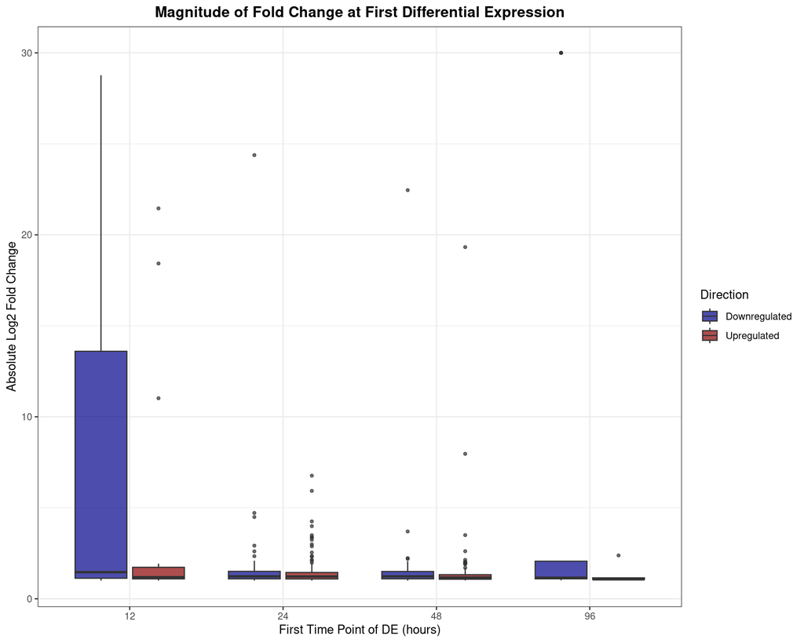

```r
# Examine magnitude of fold change at first DE by time point
ggplot(first_de_timepoint, aes(x = factor(first_de_time), y = abs(fc_at_first_de),
                             fill = direction_at_first_de)) +
  geom_boxplot(alpha = 0.7, outlier.size = 1) +
  scale_fill_manual(values = c("Upregulated" = "darkred", "Downregulated" = "darkblue")) +
  labs(title = "Magnitude of Fold Change at First Differential Expression",
       x = "First Time Point of DE (hours)",
       y = "Absolute Log2 Fold Change",
       fill = "Direction") +
  theme_bw() +
  theme(legend.position = "right",
        plot.title = element_text(hjust = 0.5, face = "bold"))
```

## Gene Set Overlap Analysis

We’ll now examine how sets of differentially expressed genes overlap across time points using UpSet plots. This analysis aims to identify genes with transient versus persistent responses to doxycycline, helping characterize the durability of expression changes and potentially distinguishing between adaptive and sustained effects. These plots again focus specifically on genes showing significant expression changes (stringent threshold: log2FC > 1, padj < 0.05) across different time points.

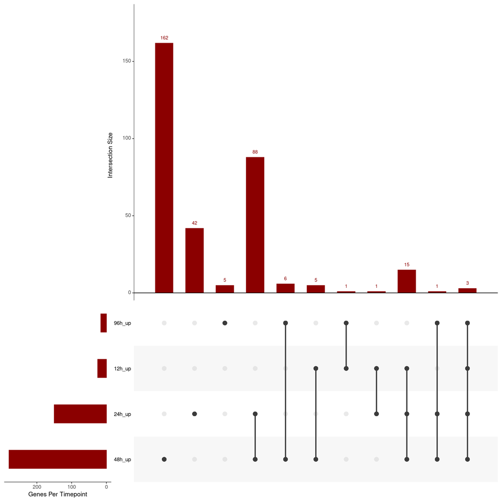

```r
library(grid) # This package is needed for adding titles to UpSet plots, but the result is inconsistent: https://github.com/hms-dbmi/UpSetR/issues/76

# Create lists of significant genes at each time point
sig_genes_by_timepoint <- list()
for(time_point in unique_timepoints) {
  # Upregulated genes
  up_genes <- filtered_res_df_stringent %>%
    filter(result_name == paste0("time_point_", time_point, "_vs_0"),
           log2FoldChange > 0) %>%
    pull(gene_id)

  # Downregulated genes
  down_genes <- filtered_res_df_stringent %>%
    filter(result_name == paste0("time_point_", time_point, "_vs_0"),
           log2FoldChange < 0) %>%
    pull(gene_id)

  # Store in lists
  sig_genes_by_timepoint[[paste0(time_point, "h_up")]] <- up_genes
  sig_genes_by_timepoint[[paste0(time_point, "h_down")]] <- down_genes
}

# Create an UpSet plot to visualize the overlap between upregulated genes across time points
up_gene_sets <- sig_genes_by_timepoint[grep("_up$", names(sig_genes_by_timepoint))]
upset_data_up <- fromList(up_gene_sets)
names(upset_data_up) <- factor(names(upset_data_up), # An attempt to pass the order explicitly, to no avail
                               levels = c("12h_up", "24h_up", "48h_up", "96h_up"))

upset(upset_data_up, sets = names(upset_data_up), # Chronological order overridden by UpSetR
      main.bar.color = "darkred", sets.bar.color = "darkred",
      text.scale = 1.3, point.size = 3.5, line.size = 1,
      mainbar.y.label = "Intersection Size", sets.x.label = "Genes Per Timepoint",
      mb.ratio = c(0.6, 0.4),
      # Need grid to show title (this doesn't work consistently: https://github.com/hms-dbmi/UpSetR/issues/76)
      grid.text("Overlap of Significantly Upregulated Genes",x = 0.65, y=0.95, gp=gpar(fontsize=10)))
```

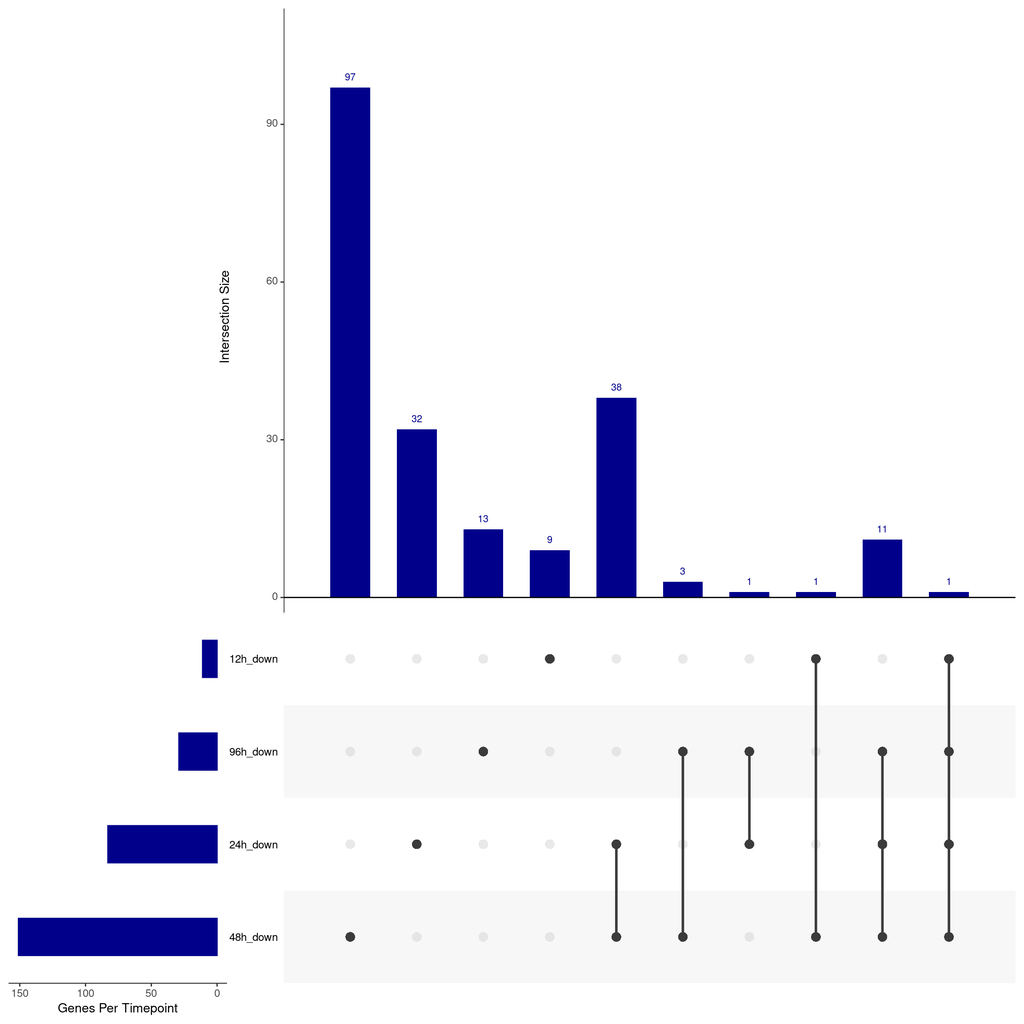

```r
# Create an UpSet plot for downregulated genes
down_gene_sets <- sig_genes_by_timepoint[grep("_down$", names(sig_genes_by_timepoint))]
upset_data_down <- fromList(down_gene_sets)
names(upset_data_down) <- factor(names(upset_data_down), # An attempt to pass the order explicitly, to no avail
                               levels = c("12h_down", "24h_down", "48h_down", "96h_down"))

# Create UpSet plot for downregulated genes
upset(upset_data_down, sets = names(upset_data_down),  # Chronological order overridden by UpSetR
      main.bar.color = "darkblue", sets.bar.color = "darkblue",
      text.scale = 1.3, point.size = 3.5, line.size = 1,
      mainbar.y.label = "Intersection Size", sets.x.label = "Genes Per Timepoint",
      mb.ratio = c(0.6, 0.4),
      # Need grid to show title (this doesn't work consistently: https://github.com/hms-dbmi/UpSetR/issues/76)
      grid.text("Overlap of Significantly Downregulated Genes",x = 0.65, y=0.95, gp=gpar(fontsize=10)))
```

```r
# Find genes that are consistently differentially expressed across all time points
all_timepoints <- paste0(unique_timepoints, "h_up")
consistent_up_genes <- Reduce(intersect, up_gene_sets)
consistent_down_genes <- Reduce(intersect, down_gene_sets)

cat("Number of consistently upregulated genes across all time points:", length(consistent_up_genes), "\n")
```

```
## Number of consistently upregulated genes across all time points: 3
```

```r
cat("Number of consistently downregulated genes across all time points:", length(consistent_down_genes), "\n")
```

```
## Number of consistently downregulated genes across all time points: 1
```

```r
consistent_up_gene_names <- g2s$gene_name[match(consistent_up_genes, g2s$gene_id)]
consistent_down_gene_names <- g2s$gene_name[match(consistent_down_genes, g2s$gene_id)]

cat("\nTop consistently upregulated genes:\n")
```

```
##
## Top consistently upregulated genes:
```

```r
cat(paste(head(consistent_up_gene_names, 20), collapse = ", "), "\n")
```

```
## Gm28438, Gm48423, Gm20075
```

```r
cat("\nTop consistently downregulated genes:\n")
```

```
##
## Top consistently downregulated genes:
```

```r
cat(paste(head(consistent_down_gene_names, 20), collapse = ", "), "\n")
```

```
## Mageb16-ps2
```

### Discussion

- The expression patterns following doxycycline treatment presented in the UpSet plots reveal distinct waves of transcriptional response in mouse stem cells. All upregulated and downregulated time point responses show both unique and overlapping gene sets. Gene expression overlap is common between 24 and 48 hour time points, however, few genes expressed during the 12 and 96 hour time points overlap with each other and/or the 24 and 48 hour time points likely implying a coordinated regulatory cascade rather than a uniform response. 12/96 overlap with 24/48 exhibits high upregulation with the 12 hour timepoint (i.e. 12-24-48 have a greater intersection size than 24-48-96) and high downregulation with the 96 hour timepoint. This trend also supports the previous conclusion of the upregulated expression of a cascade pathway occurring over the 96 hour test.
- Consistently expressed or repressed genes tend to be predicted genes or pseudogenes, with their functions likely being regulatory rather than protein-coding.

Consistently upregulated genes:

- Gm28438 and Gm48423 non-coding RNAs that haven’t been fully characterized in mouse stem cells. Their consistent upregulation across all timepoints suggests they may either play important regulatory roles in the cellular response to doxycycline or have a high enhancer affinity for the drug without relation to the genes’ transcribed or independent functions, both potentially affecting stem cell state maintenance or differentiation processes.
- Gm20075 is a potentially interesting gene identified as protein-coding and synonymous with the BTF3L4B gene, orthologous to human BTF3L4. BTF3L4 plays a role in influencing protein binding and contributing to the growth and metastasis of certain cancers, suggesting its consistent upregulation in mouse stem cells could have cellular differentiation and/or maintenance implications.

Consistently downregulated gene:

- Mageb16-ps2 is a pseudogene related to the MAGE (Melanoma Antigen Gene) family, specifically Mageb16. MAGE family genes are typically involved in cell cycle regulation, apoptosis, and cellular differentiation. The consistent downregulation of Mageb16-ps2 might indicate alteration of cell cycle or differentiation pathways throughout the doxycycline response.